# FinalMACDataAnalysis

## Data Analysis for MAC

### By Ben Wetcheme, Adithya Gopinath, Caleb Schwartzman, Diana Brady

#### **Introduction:**

Through our comprehensive data analysis, we seek a deeper understanding of the relationship locally-sourced food communities have with workforce development outcomes. As the agriculture field in Maryland is less invested in apprenticeships, MAC desires to create a pitch to agricultural stakeholders on the benefits apprenticeships could bring. This project aims to look for economic, wellness, jobs, and other factors that benefit the communities so that we can help MAC supplement its current evidence and arguments.

The data analysis notebook’s layout is meant to be readable by anyone meaning stakeholders in the agricultural field, MAC employees, and people who have no relevance to the topic. This means we provide extensive information to explain what the reader is trying to understand.

#### **Background Information for Apprenticeships:**

**What are apprenticeships and where are they incorporated?**

“Apprenticeships combine paid on-the-job training with classroom instruction to prepare workers for highly-skilled careers” (U.S. Department of Labor). By allowing students to have combined instruction and experience in their specialty, employers can facilitate the transition into the workforce through apprenticeships.

**Why are apprenticeships needed in the Agricultural field and the potential opportunities associated?**

Before we start our data analysis which will provide numbers supporting whether or not we need apprenticeships in the agricultural field, we compiled reasons describing the importance of apprenticeships.

- Technology is surfacing, which provides the opportunity for agricultural stakeholders to take advantage of incorporating it into their work.
  - Agtech is an example of a company that has been working towards implementing automation and machine learning in the agricultural ecosystem. The need for new technology on farms brings the necessity for workers who have the education and hands-on experience to work and monitor these machines' progress. Currently, there is not a lot of data on whether these technologies are more cost-efficient than current farming techniques. The companies creating these technological products are still prototyping in the farms, so to prevent competition, they classify their data as private, which brings a risk of uncertainty with these products. However, this should not falter us in our quest to find more efficient farming techniques. Having apprenticeships revolving around technology can help prototype these technologies while helping the workforce.
  - Another point of opportunity is through UMD. University of Maryland has a premiere agricultural department, and recently announced that they are opening an artificial intelligence program. These two programs can invest into apprenticeships for high schoolers in the agricultural department and provide a proper support system academically.

**What are benefits of having these apprenticeship programs?**

- With new agricultural technology, farms and AI companys can have knowledgable people working on and managing these technology.
- Opportunity for major financial gain
  - Requires investment in workforce as people need to constantly monitor the technology, which creates a new specialization

#### **Background Information for Locally Sourced Food:**

**What is Locally Sourced Food?**

The definition of locally sourced food is exactly as it sounds: food procured from a nearby location. The US Department of Agriculture's conditions for classifying locally sourced food is "less than 400 miles from the origin of the product, or within the state in which the product is produced" (Tropp). Locally sourced food limits people's dietary choices due to specific crops and meat being harvested based on the location’s environment. As there are specializations due to location, consumers can often find locally sourced food in farmers' markets and stores, although not limited.

**Locally Sourced Food in Maryland**

Locally sourced food is all over the country. According to the US Environmental Protection Agency (EPA), an assistance program known as the Local Foods, Local Places (LFLP) "helps cities and towns across the country engage with stakeholders to develop local food systems" (EPA). This program is between the EPA, Appalachian Regional Commission, and the US Department of Agriculture (USDA). Projects included opening year-round markets with food from local farmers, creating food hubs to market local foods, making them more accessible through the Supplemental Nutrition Assistance Program (SNAP), and much more. The most recent partner communities from Maryland, in 2016, were Baltimore and Crisfield.

As mentioned above, locally sourced food communities have a reduced variety of diets. However, they still have access to a lot of food. In the state of Maryland, represented by the graphic below provided by the Maryland Department of Agriculture website, many types of crops are grown.

[figure not shown]

**What are the argued benefits of locally sourced food? Argued disadvantages?**

Locally sourced food is said to have multiple benefits. According to Rita Klavinski (2013) of Michigan State University, some benefits include:

- More flavor as crops are picked at the peak of their ripeness rather than earlier (crops are picked earlier so they can be shipped to grocery stores)
- More nutrients as the nutrient value decreases the longer they sit which happens when food is shipped to further places
- Supports the local economy as the money spent is reinvested into the local businesses
- Environment benefits as local farmland is maintained better due to the constant demand and reinvestment
- Safer food supply as there are fewer chances for contamination due to the shorter supply chain

In the article *Benefits of Eating Locally Sourced Foods* (American Board of Physician Specialties), the writers introduce the term "food as medicine." This is used to describe the role food plays in maintaining people's health. Highly processed foods can increase the chances of heart disease, but locally sourced food, which is rich in nutrients and requires less processing, can serve as medicine.

Although there are many positives of locally sourced food, there are arguments that contrast the good. Helen Nilsson (2009) brings up potential disadvantages such as more labor-intensive work and a more expensive production system. This can lead to the cost of food being more expensive as there needs to be compensation for the cost of production. In addition, she brings up how energy is not used efficiently due to the distance covered by transportation. Another environmental argument brought up in a Scienceline article by Jonathan Moens (2020), raises the misconception believed by many that most international imports are transported by plane. However, the truth is that they account for .16% of global food transportation, and the leading transportation style is by sea, which is 60%. In addition, transportation by sea releases about 50 times less greenhouse emissions. In the analysis that is brought up, due to our heavy consumption of red meats, more greenhouse emissions are released from the methane of cow flatulence. The main criticism in this article is not the system of locally sourced food, but rather the demand for meat that drives locally sourced food producers to focus on red meat.

#### **Code Preparation**

```python
# Installing necessary packages

!pip install openpyxl
!pip install scikit-learn
!pip install statsmodels
!pip install xlrd>=2.0.1
```

```python
# Importing Libraries

import pandas as pd
import numpy as np
import matplotlib.pyplot as plt
%matplotlib inline
```

#### **Maryland Apprenticeships Analysis**

Data File Used: 'MDLabor.xlsx'

Source: Maryland Apprenticeship Connector

Link: https://docs.google.com/spreadsheets/d/1gdgR7mMAFxxknxFJz6DyumTo7KQ_Lz6s/edit?usp=sharing&ouid=102654314159304527513&rtpof=true&sd=true

Description: This Maryland Apprenticeship Connector-provided dataset provides details on the apprenticeship & workforce in Maryland. We chose to analyze the data in this data collection as it can provide context on specific areas that are flourishing and others that are struggling. Conducting a descriptive analysis can begin the train of thought regarding what is working and is not regarding the workforce, and more specifically, in the agricultural field (we will later analyze agricultural data to make connections). The specific Apprenticeship data we looked at was taken from the Youth Apprenticeship Advisory Commitee Annual Reports.

```python
# Read MAC Labor Dataset

file_path_labor = 'MDLabor.xlsx'
sheet_name1 = 'Apprenticeships (year-end)'
df1 = pd.read_excel(file_path_labor, sheet_name= sheet_name1)
```

##### *Data Cleaning*

```python
#a. Drop Maryland row since it's a sum of the counties. This interferes with the graphing. Drop Baltimore City as it is an individual city. Delete the Share and Per 1000 columns as they're unneccessary for the analysis. Lastly, get rid of the NA rows.
df1.drop(df1[df1['Counties'] == 'Maryland'].index, inplace = True)
df1.drop(df1[df1['Counties'] == 'Baltimore City'].index, inplace = True)
df1_delete = ['Share of Total Yas 2022-2023','YAs per 11+12 Graders in Public (per 1000) 2021-2022']
df1.drop(columns=df1_delete, inplace=True)
df1.dropna(inplace=True)

#b. Rename columns for better readability
df1.rename(columns={'Total Youth Apprenticeships (Year-End) 2017-2018': '2017-2018',
                            'Total Youth Apprenticeships (Year-End) 2018-2019':'2018-2019',
                            'Total Youth Apprenticeships (Year-End) 2019-2020':'2019-2020',
                            'Total Youth Apprenticeships (Year-End) 2020-2021':'2020-2021',
                            'Total Youth Apprenticeships (Year-End) 2021-2022':'2021-2022',
                            'Total Youth Apprenticeships (Mid-Year, December) 2022-2023':'2022-2023'}, inplace=True)

# Display table for accuracy (commented out for overall readbility of notebook; remove '#' to look at table)
display(df1)
```

|  | Counties | 2017-2018 | 2018-2019 | 2019-2020 | 2020-2021 | 2021-2022 | 2022-2023 |
| --- | --- | --- | --- | --- | --- | --- | --- |
| 0 | Washington County | 15.0 | 23.0 | 13.0 | 22.0 | 90.0 | 107.0 |
| 1 | St. Mary's County | 0.0 | 0.0 | 0.0 | 6.0 | 24.0 | 41.0 |
| 2 | Anne Arundel County | 0.0 | 0.0 | 0.0 | 0.0 | 1.0 | 149.0 |
| 3 | Howard County | 0.0 | 0.0 | 19.0 | 23.0 | 20.0 | 33.0 |
| 4 | Queen Anne's County | 0.0 | 0.0 | 5.0 | 0.0 | 4.0 | 4.0 |
| 5 | Allegany County | 0.0 | 0.0 | 3.0 | 1.0 | 4.0 | 4.0 |
| 6 | Caroline County | 0.0 | 0.0 | 0.0 | 0.0 | 1.0 | 2.0 |
| 7 | Baltimore County | 0.0 | 0.0 | 0.0 | 4.0 | 10.0 | 38.0 |
| 8 | Frederick County | 12.0 | 23.0 | 21.0 | 19.0 | 12.0 | 15.0 |
| 9 | Harford County | 0.0 | 0.0 | 0.0 | 0.0 | 0.0 | 11.0 |
| 10 | Talbot County | 0.0 | 1.0 | 8.0 | 4.0 | 3.0 | 1.0 |
| 11 | Calvert County | 0.0 | 0.0 | 0.0 | 0.0 | 3.0 | 3.0 |
| 12 | Wicomico County | 0.0 | 0.0 | 0.0 | 0.0 | 1.0 | 1.0 |
| 13 | Carroll County | 0.0 | 0.0 | 0.0 | 0.0 | 0.0 | 2.0 |
| 14 | Montgomery County | 0.0 | 0.0 | 0.0 | 0.0 | 4.0 | 9.0 |
| 15 | Prince George's County | 0.0 | 0.0 | 0.0 | 0.0 | 0.0 | 2.0 |
| 17 | Cecil County | 0.0 | 0.0 | 0.0 | 0.0 | 0.0 | 0.0 |
| 18 | Charles County | 0.0 | 0.0 | 0.0 | 0.0 | 0.0 | 0.0 |
| 19 | Dorchester County | 0.0 | 0.0 | 3.0 | 8.0 | 7.0 | 0.0 |
| 20 | Garrett County | 0.0 | 0.0 | 0.0 | 0.0 | 0.0 | 0.0 |
| 21 | Kent County | 0.0 | 0.0 | 2.0 | 2.0 | 0.0 | 0.0 |
| 22 | Somerset County | 0.0 | 0.0 | 0.0 | 0.0 | 0.0 | 0.0 |
| 23 | Worcester County | 0.0 | 0.0 | 0.0 | 0.0 | 0.0 | 0.0 |

##### *Descriptive Analysis*

```python
# Five Number Summary For Each Column
df1_five_num = df1.describe().loc[['min', '25%', '50%', '75%', 'max']]

display(df1_five_num)
```

|  | 2017-2018 | 2018-2019 | 2019-2020 | 2020-2021 | 2021-2022 | 2022-2023 |
| --- | --- | --- | --- | --- | --- | --- |
| min | 0.0 | 0.0 | 0.0 | 0.0 | 0.0 | 0.0 |
| 25% | 0.0 | 0.0 | 0.0 | 0.0 | 0.0 | 0.0 |
| 50% | 0.0 | 0.0 | 0.0 | 0.0 | 1.0 | 2.0 |
| 75% | 0.0 | 0.0 | 3.0 | 4.0 | 5.5 | 13.0 |
| max | 15.0 | 23.0 | 21.0 | 23.0 | 90.0 | 149.0 |

##### **What do we see?**

The five number summary displays the minimum, first quartile, median, 3rd quartile, and maximum value for the apprenticeship count from 2017 to 2023.

```python
# Mean of Maryland Apprenticeships

mean_dict1 = {}
for col in df1:
    if df1[col].dtype in ['float64']:
        m = df1[col].mean()
        mean_dict1[col] = m
mean_df1 = pd.DataFrame({'Years': list(mean_dict1.keys()), 'Mean of MD Apprenticeships per year': list(mean_dict1.values())})
display(mean_df1)
```

|  | Years | Mean of MD Apprenticeships per year |
| --- | --- | --- |
| 0 | 2017-2018 | 1.173913 |
| 1 | 2018-2019 | 2.043478 |
| 2 | 2019-2020 | 3.217391 |
| 3 | 2020-2021 | 3.869565 |
| 4 | 2021-2022 | 8.000000 |
| 5 | 2022-2023 | 18.347826 |

##### **What do we see?**

The mean apprenticeships table illustrates the number of mean apprenticeships in the state of Maryland recorded over the years 2017 to 2023. The number increases every year due to more counties gaining apprenticeships and some counties singificantly increasing their count. There were accelerated jumps between 2020 to 2023, indicating the increasing investment in apprenticeships.

```python
# Median of Maryland Apprenticeships
median_dict1 = {}
for col in df1:
    if df1[col].dtype in ['float64']:
        m = df1[col].median()
        median_dict1[col] = m
median_df1 = pd.DataFrame({'Years': list(median_dict1.keys()), 'Median of MD Apprenticeships per year': list(median_dict1.values())})
display(median_df1)
```

|  | Years | Median of MD Apprenticeships per year |
| --- | --- | --- |
| 0 | 2017-2018 | 0.0 |
| 1 | 2018-2019 | 0.0 |
| 2 | 2019-2020 | 0.0 |
| 3 | 2020-2021 | 0.0 |
| 4 | 2021-2022 | 1.0 |
| 5 | 2022-2023 | 2.0 |

##### **What do we see?**

The median apprenticeships table illustrates the number of median apprenticeships in the state of Maryland recorded over the years 2017 to 2023. It can be seen that only from 2021 to 2023 that the median value is different from 0. This table was simply made to compare with the mean table. The median values can also be seen in the five number summary table above.

##### *Visualizations*

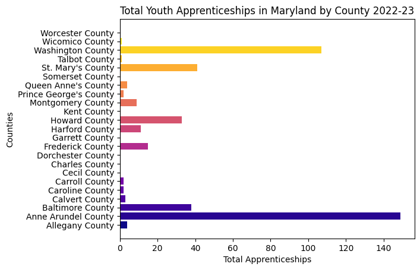

```python
# Bar Chart to display the differences between each county's total apprenticeships in 2022-23

num_apprenticeships = df1.groupby('Counties')['2022-2023'].sum()
colors = plt.cm.plasma(np.linspace(0,1,len(num_apprenticeships)))

plt.barh(num_apprenticeships.index, num_apprenticeships, color = colors)

plt.xlabel('Total Apprenticeships')
plt.ylabel('Counties')
plt.title('Total Youth Apprenticeships in Maryland by County 2022-23')
plt.show()
```

##### **What do we see?**

This is a bar chart displaying the number of apprenticeships there were from the year of 2022 to 2023 (mid-December). It can be seen that Anne Arundel and Washington County boast apprenticeship counts over 100, St. Mary's, Baltimore, and Howard County are close to 40, and Allegany, Calvert, Caroline, Carroll, Harford, Montgomery, Prince George's, Queen Anne's, Talbot, and Wicomico County have apprenticeships. This chart can be used to identify areas of potential, areas that need to be addressed such as the apprenticeships with barely or no apprenticeships, and the counties that are 'thriving.'

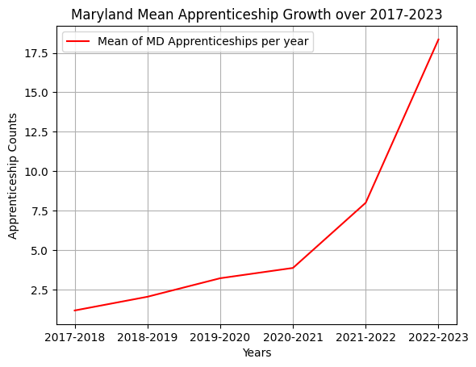

```python
# Line Graph for Maryland Apprenticeships throughout the years (2017-2023)

mean_df1.plot.line(x='Years', grid=True, color='red')
plt.xlabel('Years')
plt.ylabel('Apprenticeship Counts')
plt.title('Maryland Mean Apprenticeship Growth over 2017-2023')
plt.show()
```

##### **What do we see?**

This line chart displays the growth of average mean apprenticeships in Maryland from 2017 to 2023 represented by the mean table from above. This chart visualizes the increase in apprenticeships with every year.

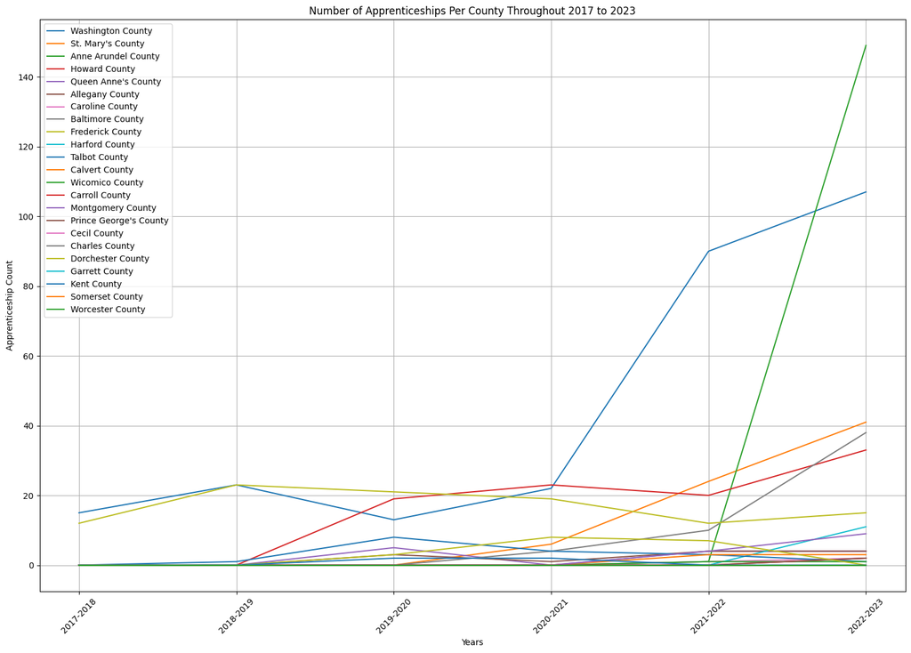

```python
# Plot Line Graph for Apprenticeships Per County throughout the years (2017-2023)

df1.set_index('Counties', inplace=True)
plt.figure(figsize=(15, 10))

for county in df1.T:
    plt.plot(df1.T.index, df1.T[county], label=county)
plt.legend()
plt.grid(True)
plt.tight_layout()
plt.xlabel('Years')
plt.ylabel('Apprenticeship Count')
plt.title('Number of Apprenticeships Per County Throughout 2017 to 2023')
plt.xticks(rotation=45)
plt.show()
```

##### **What do we see?**

This line chart displays the change of apprenticeship count by county with every year. As it can be seen, some counties show slight increases and decreases. This chart displays the significant gaps between counties such as Anne Arundel and Washington as they have triple-digit counts while the other counties do not.

**MAC Apprenticeship Analysis Closing Summary**

We conducted a short descriptive analysis to examine and understand the data. The five-number summary contained many zeroes, however, the median, third quartile, and maximum displayed growth. For the mean apprenticeship count, there was a steady increase until 2021-2022, which more than doubled from the previous year. The year after followed the trend, displaying potential for growth. We conducted a median test for each year as well. As the overall median is below the mean values for each year, it is important to note that the data is more skewed towards the maximum values, which means that the most extreme values are higher apprenticeship counts. However, the apprenticeship growth in individual counties is still an accomplishment towards the goal of working towards providing high schoolers with more opportunity.

For visualizations, we decided to conduct a bar graph, line graph of the mean apprenticeships for Maryland across time, and another line graph that displays the growth of apprenticeships by county. Our goal was to exhibit the relationship between the amount of apprenticeships and counties. In the bar graph, we implemented colorful coding to differentiate each county. Anne Arundel and Washington county lead the counties by a sizable margin whereas many of the counties have [close to] none. For the line graph displaying the counties, we wanted to reveal any jumps or decreases throughout the years. Most of the counties stayed consistent with their numbers, but Washington County had a major jump from 2020-2021 to 2021-2022 and Anne Arundel went from almost none to over one hundred. The line graph for the mean apprenticeship growth for the state of Maryland starts to exponentially grow after 2020. Although the sample size is small with the amount of years that have been tracked, it is important to note the current proof of growth.

Overall, it is arguably a safe assumption that the amount of apprenticeships in Maryland will grow through the investment in apprenticeships in individual counties. As different counties start to implement more apprenticeship roles in their communities, others will start to take notice, which brings the type of work more publicity and credibility.

#### **Workforce Data Analysis**

Data File: 'RuralAtlasData24.xlsx'

Source: ers.usda.gov

Link: https://www.ers.usda.gov/data-products/atlas-of-rural-and-small-town-america/

Description: This source provides multiple statistics on variables such as jobs and people. The context we are using this in is to analyze workforce patterns. The data is of April 7th, 2023, which serves as a recent source. The data in this dataset was taken from sources such as the Deccenial Census of Population and Housing, American Community Survey, Loocal Area Unemployment Statistics (LAUS), and other federal sources. The US Bureau of the Census and USDA were cited as sources, which are federal entities.

```python
# Read Rural Atlas Dataset

file_path_labor = 'RuralAtlasData24.xlsx'
sheet_name_jobs = 'Jobs'
sheet_name_people = 'People'

df2_RuralAtlas = pd.read_excel(file_path_labor, sheet_name = sheet_name_jobs)
df2_RuralAtlas_Education = pd.read_excel(file_path_labor, sheet_name = sheet_name_people)
```

```python
# Data Cleaning

# Narrow both dataframes to Maryland State values only, remove Baltimore City (using FIPS due to duplicate name) and Maryland state values

df2_RuralAtlas_MD_Counties = df2_RuralAtlas[df2_RuralAtlas['State'] == 'MD']
df2_RuralAtlas_MD_Counties = df2_RuralAtlas_MD_Counties[df2_RuralAtlas_MD_Counties['FIPS']!=24510]
df2_RuralAtlas_MD_Counties = df2_RuralAtlas_MD_Counties[df2_RuralAtlas_MD_Counties['County']!='Maryland']

# display (df2_RuralAtlas_MD_Counties)
```

```python
df2_RuralAtlas_Education_Counties = df2_RuralAtlas_Education[df2_RuralAtlas_Education['State'] == 'MD']
df2_RuralAtlas_Education_Counties = df2_RuralAtlas_Education_Counties[(df2_RuralAtlas_Education_Counties['FIPS']!=24510)&(df2_RuralAtlas_Education_Counties['County']!='Maryland')]

# display(df2_RuralAtlas_Education_Counties)
```

##### *Part 1 - People Sheet*

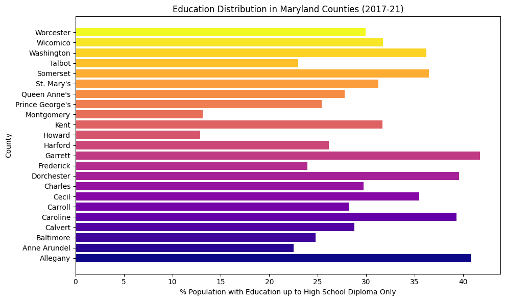

```python
# Visualization of % of Counties with only a high school diploma/GED only, adults 25 and over from 2017-21

education_cols = df2_RuralAtlas_Education_Counties[['County', 'Ed2HSDiplomaOnlyPct']]

plt.figure(figsize = (10, 6))
plt.barh(education_cols['County'], education_cols['Ed2HSDiplomaOnlyPct'], color = colors)
plt.xlabel('% Population with Education up to High School Diploma Only')
plt.ylabel('County')
plt.title('Education Distribution in Maryland Counties (2017-21)')
plt.tight_layout()
```

##### **What do we see?**

This bar graph illustrates the percentage of a county's population with only a high school equivalent education in the state of Maryland. This data is from 2017 to 2021 and accounts for adults over the age of 25. The interpretation of this graph would be that the counties with a higher percentage have less people who went to school after high school. This provides valuable insight into which counties may need investing in regarding providing equitable opportunties to students.

##### *Part 2 - Jobs Sheet*

```python
# Analyzing How Unemployment Changed from 2020 to 2021 For Each Maryland County

# Setting variables for Unemployment Rate in 2020 & 2021

df2_RuralAtlas_MD_Counties.reset_index()
counties = df2_RuralAtlas_MD_Counties['County'].reset_index()
UnempRate_2021 = df2_RuralAtlas_MD_Counties['UnempRate2021'].reset_index()
UnempRate_2020 = df2_RuralAtlas_MD_Counties['UnempRate2020'].reset_index()

# UnempRate_2021
# UnempRate_2020

unemployment_change = pd.merge(UnempRate_2021 ,UnempRate_2020,  on='index', how='outer')
# unemployment_change

# Showing Percentage Change in Unemployment Rate Between 2020 & 2021

unemployment_change['PercentageChange'] = ((unemployment_change['UnempRate2021'] - unemployment_change['UnempRate2020'])/unemployment_change['UnempRate2020']) * 100
# display(unemployment_change)

avg_percentage_change = unemployment_change['PercentageChange'].mean()
print("Average Percentage Change:", avg_percentage_change)
```

```
Average Percentage Change: -15.774196814184588
```

##### **What do we see?**

The percent change from 2020 to 2021 was calculated for each county. The mean of all of the percent changes in unemployment was taken which resulted in -15.8%. The percent change for each county was negative, which is positive as it means that more people became employed.

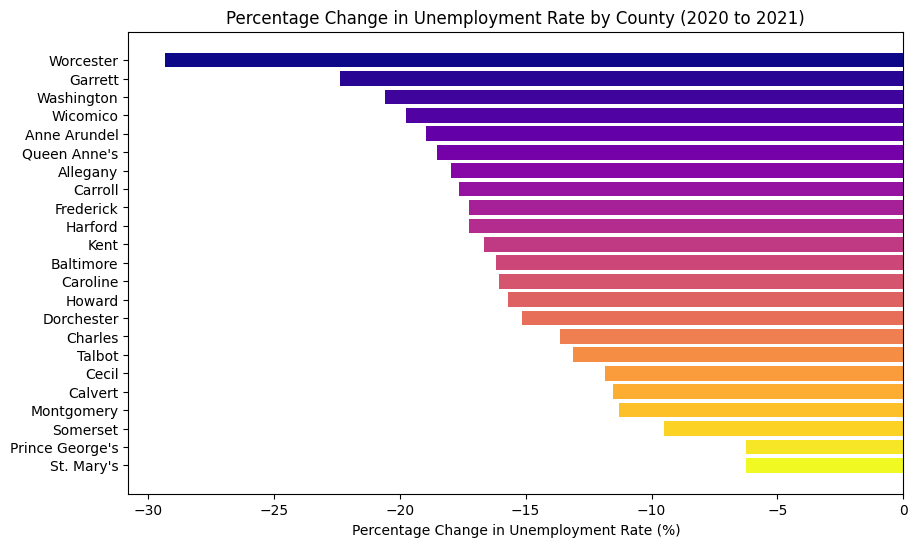

```python
# Visualization of Percentage Change in Unemployment Rate by County from 2020 to 2021

unemployment_state = pd.merge(counties ,unemployment_change, on='index', how='inner')
# unemployment_state

unemployment_state.sort_values(by='PercentageChange', inplace=True)

plt.figure(figsize=(10, 6))
plt.barh(unemployment_state['County'], unemployment_state['PercentageChange'], color=colors)
plt.xlabel('Percentage Change in Unemployment Rate (%)')
plt.title('Percentage Change in Unemployment Rate by County (2020 to 2021)')
plt.gca().invert_yaxis()
plt.show()
```

##### **What do we see?**

This visualization displays the percentage change in unemployment rate from 2020 to 2021. There was approximately a 30% decrease in unemployment in Worchester County, which means that the county exhibited the most significant growth in employment. St. Mary's and Prince George's County displays the least decrease in unemployment, which meant that they had a larger % of their own population that needed jobs compared to the other counties. It's important to note that as of 2024, the data could be different, but this provides general insight to the patterns and trends of unemployment.

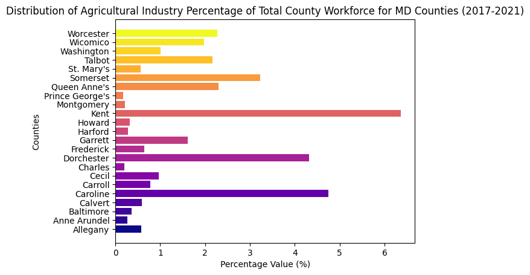

```python
# Visualization for Agricultural Industry Makeup of Workforce in Each Maryland County (2017-2021)

df_MDPercentage = df2_RuralAtlas_MD_Counties
df_MDPercentage.rename(columns={'PctEmpAgriculture': 'Agriculture',
                            'PctEmpConstruction':'Construction',
                            'PctEmpMining':'Mining', 'PctEmpManufacturing':'Manufacturing',
                            'PctEmpTrade':'Wholesale & Retail Trade', 'PctEmpTrans':'Transporation',
                            'PctEmpInformation':'Information', 'PctEmpFIRE':'Finance, Insurance, and Real Estate',
                            'PctEmpServices':'Services', 'PctEmpGovt':'Public Administration'}, inplace=True)
df_MDPercentage_col =  ['County','Agriculture', 'Mining','Construction', 'Manufacturing',
                        'Wholesale & Retail Trade', 'Transporation', 'Information', 'Finance, Insurance, and Real Estate', 'Services', 'Public Administration']

df_MDPercentage = df_MDPercentage[df_MDPercentage_col]

pct_emp_agr = df_MDPercentage.groupby('County')['Agriculture'].sum()
colors = plt.cm.plasma(np.linspace(0,1,len(pct_emp_agr )))

plt.barh(pct_emp_agr.index, pct_emp_agr , color = colors)

plt.xlabel('Percentage Value (%)')
plt.ylabel('Counties')
plt.title('Distribution of Agricultural Industry Percentage of Total County Workforce for MD Counties (2017-2021)')
```

##### **What do we see?**

This visualization displays how the percentage that the agricultural industry makes up of each county's workforce. Factors like population of each county should be taken into consideration, but Kent County has the biggest percentage of agricultural workers in its workforce. Another consideration is that other counties may have a dominating workforce that affects the percentage of other industries. An example of potential external factors affecting the percent value would be Frederick and Carroll County. In the next part of this data analysis, it'll be shown that those two counties significantly have the most farms as of 2017. However, this visualization exhibits a below 1% workforce makeup, which is important to note.

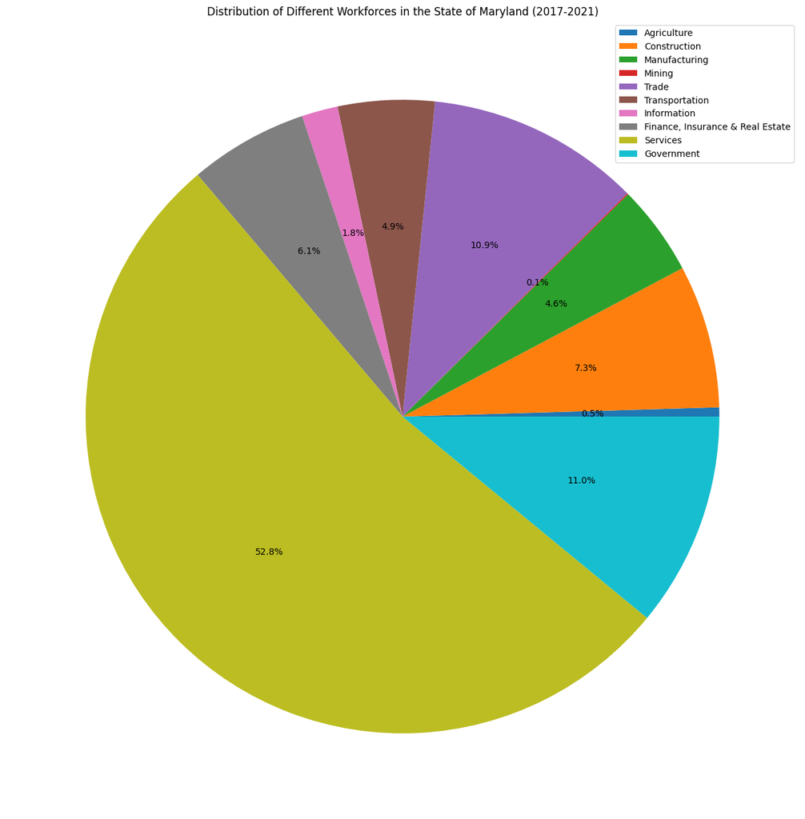

```python
# Pie Chart of Different Industries Workforce in MD
df_MDPercentage_Pie = df2_RuralAtlas[(df2_RuralAtlas['State'] == 'MD') & (df2_RuralAtlas['County'] == 'Maryland')]

df_MDPie_Col = { 'PctEmpAgriculture': 'Agriculture', 'PctEmpConstruction': 'Construction',  'PctEmpManufacturing': 'Manufacturing',
    'PctEmpMining': 'Mining', 'PctEmpTrade': 'Trade',
    'PctEmpTrans': 'Transportation', 'PctEmpInformation': 'Information',
    'PctEmpFIRE': 'Finance, Insurance & Real Estate', 'PctEmpServices': 'Services',  'PctEmpGovt': 'Government'}

df_MDPercentage_Pie.rename(columns=df_MDPie_Col, inplace=True)
workforce_cols = list(df_MDPie_Col.values())
df_MDPercentage_Pie = df_MDPercentage_Pie[workforce_cols]
total_values = df_MDPercentage_Pie.sum()
total_values.plot(kind='pie', labels=None, figsize=(16, 16), autopct='%1.1f%%', legend=True, title="Distribution of Different Workforces in the State of Maryland (2017-2021)", fontsize=10)
```

#### **Maryland Farms Analysis**

Data Files Used: MD_Number_of_Farms

Source: Maryland.gov Open Data Portal

Link: https://opendata.maryland.gov/Agriculture/Maryland-Number-of-Farms-Change-in-Farms-and-Perce/kk7p-trej/data?no_mobile=true

Description: This dataset has statistics on the number of farms in Maryland throughout 2002 to 2017. This is taken from Maryland's Open Data Portal. It was created in 2014 and last updated in 2018. The agency in charge of the data is the Maryland Department of Planning, citing its credibility.

```python
# Import Maryland Farms Dataset & Display
df3_MDFarms = pd.read_excel( 'MDFarms.xlsx')
# display(df3_MDFarms)
```

##### *Data Cleaning*

```python
# Maryland Dataframe
df3_Maryland_Only = df3_MDFarms[df3_MDFarms['Jurisdiction'] == 'MARYLAND']
df3_Maryland_Only = df3_Maryland_Only[['Jurisdiction', 'Number of Farms, 2002', 'Number of Farms, 2007', 'Number of Farms, 2012', 'Number of Farms, 2017']]
# display(df3_Maryland_Only)

# Normal DF
df3_MDFarms = df3_MDFarms[df3_MDFarms['Jurisdiction']!= 'Baltimore City']
# display(df3_MDFarms)
```

```python
# County Dataframe - Remove Baltimore City, Maryland rows, and set columns for df

df3_MDFarms = df3_MDFarms[df3_MDFarms['Jurisdiction'] != 'Baltimore City']
df3_MDFarms = df3_MDFarms[df3_MDFarms['Jurisdiction'] != 'MARYLAND']
df3_MDFarms_Counties_Change = df3_MDFarms[['Jurisdiction', 'Number of Farms, 2002', 'Number of Farms, 2007', 'Number of Farms, 2012', 'Number of Farms, 2017']]
```

##### *Descriptive Analysis*

```python
# Mean % Growth/Regression Table
df3_MDFarms_gr = df3_MDFarms[['Jurisdiction', 'Percent Change in Farms, 2002-2017']]
# display(df3_MDFarms_gr)

# Range, mean, and median of 'Number of Farms, 2017' variable
farms_range = df3_MDFarms['Number of Farms, 2017'].max() - df3_MDFarms['Number of Farms, 2017'].min()
mean = df3_MDFarms['Number of Farms, 2017'].mean().round(0)
median = df3_MDFarms['Number of Farms, 2017'].median()

# Five Number Summary for 'Number of Farms, 2017' variable
minimum_val = df3_MDFarms['Number of Farms, 2017'].min()
quartile_1 = np.percentile(df3_MDFarms['Number of Farms, 2017'], 25)
quartile_3 = np.percentile(df3_MDFarms['Number of Farms, 2017'], 75)
maximum_val =  df3_MDFarms['Number of Farms, 2017'].max()

print(f"Five Number Summary for Number of Farms in 2017:\nmin: {minimum_val}\n25% (Q1): {quartile_1}\nmedian: {median}\n75% (Q3): {quartile_3}\nmax: {maximum_val}")
print(f"\nFor the Number of Farms in 2017, the range is {farms_range}, the mean is {mean}, and the median is {median}.\n")

# Range, mean, and median of "Percent Change in Farms, 2002-2017"
range_pct = df3_MDFarms['Percent Change in Farms, 2002-2017'].max() - df3_MDFarms['Percent Change in Farms, 2002-2017'].min()
mean_pct = df3_MDFarms['Percent Change in Farms, 2002-2017'].mean().round(2)
median_pct = df3_MDFarms['Percent Change in Farms, 2002-2017'].median().round(2)

print(f"For the % growth/decrease in farms from 2002 to 2017, the range is {range_pct}, the mean is {mean_pct}, and the median is {median_pct}.")
```

```
Five Number Summary for Number of Farms in 2017:
min: 255
25% (Q1): 356.5
median: 483.0
75% (Q3): 621.5
max: 1373

For the Number of Farms in 2017, the range is 1118, the mean is 540.0, and the median is 483.0.

For the % growth/decrease in farms from 2002 to 2017, the range is 0.35010843331351105, the mean is 0.01, and the median is 0.04.
```

##### **What do we see?**

The least amount of farms as of 2017 in a county is 255. Somerset County went from having 301 farms in 2002 to 255. The most amount of farms in 2017 is Frederick County with 1373. It increased by 0.07% from 2002 to 2017, but in 2007, it had 1442 farms, which is 69 more farms than in 2017. Queen Anne's County holds the median value of farms with 483. 25% of the counties hold up to 357 farms, another 25% have more than 622 farms.

For Maryland, the number of farms grew overall by 0.02% to 12429 farms. The county range is .35% as Caroline County grew by .16% from 2002 to 2017, and Prince George's County decreased by .19%. If the numbers were combined for both counties, there would be a net loss of 3 farms in total as Caroline County grew by 82 farms while Prince George's lost 85 farms. For the median and mean, as the median is larger than the mean, it means that the data is skewed to the negative values meaning there the extreme values are negative.

##### *Visualizations*

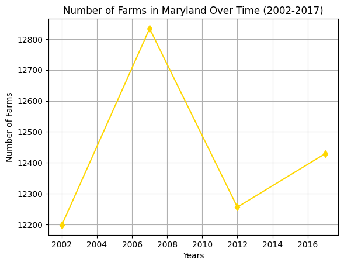

```python
# Line Graph of Number of Farms in Maryland
years = [2002, 2007, 2012, 2017]
state_farm_counts = df3_Maryland_Only.iloc[0, 1:].values.astype(int)
plt.plot(years, state_farm_counts, marker='d', color = 'gold')

plt.xlabel('Years')
plt.ylabel('Number of Farms')
plt.title('Number of Farms in Maryland Over Time (2002-2017)')
plt.grid(True)
plt.show()
```

##### **What do we see?**

This line graph shows the growth of Maryland farms over time. Although there was a general increase from 2002 to 2017. the number of farms peaked in 2007 with 12834 farms. In 2017, there were 12429, which is an upgrade from 2002 which had 12198, but it is still a 405 dropoff from 2007.

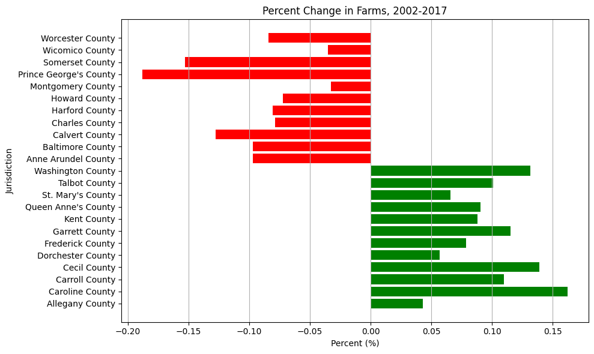

```python
# Bar Graph of Percent Change in Farms 2002-2017

df3_MDFarms_gr['Percent Change in Farms, 2002-2017'] = pd.to_numeric(df3_MDFarms_gr['Percent Change in Farms, 2002-2017'], errors='coerce')

positive_changes = df3_MDFarms_gr[df3_MDFarms_gr['Percent Change in Farms, 2002-2017'] > 0]
negative_changes = df3_MDFarms_gr[df3_MDFarms_gr['Percent Change in Farms, 2002-2017'] < 0]

plt.figure(figsize=(10, 6))

plt.barh(positive_changes['Jurisdiction'], positive_changes['Percent Change in Farms, 2002-2017'], color='green')
plt.barh(negative_changes['Jurisdiction'], negative_changes['Percent Change in Farms, 2002-2017'], color='red')

plt.xlabel('Percent (%)')
plt.ylabel('Jurisdiction')
plt.title('Percent Change in Farms, 2002-2017')
plt.grid(axis='x')

plt.tight_layout()
plt.show()
```

**MD Farms Analysis Closing Summary**

There is overall growth in Maryland's farming industry. Frederick County holds the most farms with 1373, so there is a lot of opportunity for having agricultural apprenticeships in the county. Carroll County has 1174, so it serves as a major oppurtunity as well. The median count of farms in 2017 is 483 and the mean is 540 farms. As the mean is larger than the median, this means that the Carroll and Frederick County counts influence that value. 483 farms should be looked at for the 50% quartile value, and for the counties with less farms, there should be discussions on how to maximize the output of the farms. Apprenticeships provide opportunity for those counties as well as it provides more publicity.

#### **US State Food Environmental Data Analysis**

Data Files Used: 'FoodEnvironmentalAtlas.xls'

Source: ers.usda.gov

Link: https://www.ers.usda.gov/data-products/food-environment-atlas/

Description: This dataset provides statistics related to multiple variables in the United States. These variables include Access, Stores, Restaurants, Assistance, Insecurity, Taxes, Local, Health, and Socioeconomic data. This takes data from multiple sources such as from the CDC and US Central Bureau.

```python
# Read Food Atlas Dataset

file_path_FEA = 'FoodEnvironmentAtlas.xls'
sheet_name_health = 'HEALTH'
sheet_name_locally_sourced = 'LOCAL'

df4_FEA_local =  pd.read_excel(file_path_FEA, sheet_name = sheet_name_locally_sourced)
df4_FEA_h = pd.read_excel(file_path_FEA, sheet_name = sheet_name_health)
```

##### *Data Cleaning*

```python
df4_FEA_local = df4_FEA_local[(df4_FEA_local['State']=='MD') & (df4_FEA_local['FIPS']!=24510.0)] # This was done to narrow the states to MD and remove a non-county
df4_FEA_h = df4_FEA_h[(df4_FEA_h['State'] == 'MD') & (df4_FEA_h['FIPS']!=24510.0)]
```

##### *Descriptive Analysis*

```python
# Obesity Rate for Maryland
# print(df4_FEA_h['PCT_OBESE_ADULTS17']) # 31.3 is the output
```

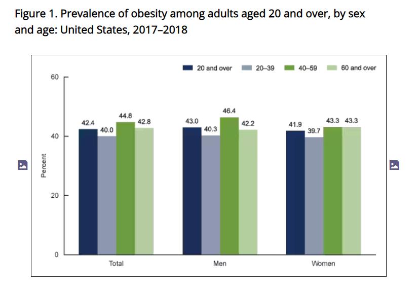

To supplement this data, the age-adjusted prevalence of obesity among U.S. adults was 42.4% in 2017, which is more than 10% compared to the obesity rate in Maryland.

```python
# Farm to school program in 2015
df4_farm_to_school_2015 = df4_FEA_local[df4_FEA_local['FARM_TO_SCHOOL15']==1] # Note - Only Garrett doesn't show up, but they had a school in 2013
# display(df4_farm_to_school_2015)
```

```python
# Table for Vegetable Farms % from 2007-2012
df4_FEA_local_vegfarmspct = df4_FEA_local[['County', 'PCH_FRESHVEG_FARMS_07_12']] # % Change
display(df4_FEA_local_vegfarmspct)
```

|  | County | PCH_FRESHVEG_FARMS_07_12 |
| --- | --- | --- |
| 1193 | Allegany | 14.285714 |
| 1194 | Anne Arundel | -52.631579 |
| 1195 | Baltimore | -18.644068 |
| 1196 | Calvert | -9.375000 |
| 1197 | Caroline | 2.777778 |
| 1198 | Carroll | -41.071429 |
| 1199 | Cecil | -19.047619 |
| 1200 | Charles | -20.833333 |
| 1201 | Dorchester | 25.000000 |
| 1202 | Frederick | -12.857143 |
| 1203 | Garrett | 11.428571 |
| 1204 | Harford | -24.242424 |
| 1205 | Howard | -26.086957 |
| 1206 | Kent | -58.333333 |
| 1207 | Montgomery | -45.454545 |
| 1208 | Prince George's | -16.326531 |
| 1209 | Queen Anne's | 19.047619 |
| 1210 | St. Mary's | -1.075269 |
| 1211 | Somerset | -35.714286 |
| 1212 | Talbot | 11.111111 |
| 1213 | Washington | -18.750000 |
| 1214 | Wicomico | -15.000000 |
| 1215 | Worcester | 50.000000 |

```python
# Table for Farmer's Market Products in 2018
df4_FEA_local_products = df4_FEA_local[['County', 'FMRKT_FRVEG18', 'FMRKT_ANMLPROD18', 'FMRKT_BAKED18', 'FMRKT_OTHERFOOD18']]
display(df4_FEA_local_products)
```

|  | County | FMRKT_FRVEG18 | FMRKT_ANMLPROD18 | FMRKT_BAKED18 | FMRKT_OTHERFOOD18 |
| --- | --- | --- | --- | --- | --- |
| 1193 | Allegany | 2.0 | 1.0 | 1.0 | 1.0 |
| 1194 | Anne Arundel | 13.0 | 8.0 | 9.0 | 9.0 |
| 1195 | Baltimore | 13.0 | 10.0 | 11.0 | 10.0 |
| 1196 | Calvert | 4.0 | 4.0 | 4.0 | 4.0 |
| 1197 | Caroline | 2.0 | 0.0 | 1.0 | 0.0 |
| 1198 | Carroll | 5.0 | 3.0 | 4.0 | 4.0 |
| 1199 | Cecil | 2.0 | 2.0 | 2.0 | 2.0 |
| 1200 | Charles | 2.0 | 1.0 | 1.0 | 1.0 |
| 1201 | Dorchester | 1.0 | 1.0 | 1.0 | 1.0 |
| 1202 | Frederick | 14.0 | 14.0 | 14.0 | 14.0 |
| 1203 | Garrett | 1.0 | 1.0 | 1.0 | 1.0 |
| 1204 | Harford | 3.0 | 3.0 | 3.0 | 1.0 |
| 1205 | Howard | 6.0 | 6.0 | 6.0 | 6.0 |
| 1206 | Kent | 1.0 | 1.0 | 1.0 | 1.0 |
| 1207 | Montgomery | 17.0 | 15.0 | 16.0 | 16.0 |
| 1208 | Prince George's | 20.0 | 16.0 | 18.0 | 15.0 |
| 1209 | Queen Anne's | 2.0 | 2.0 | 2.0 | 2.0 |
| 1210 | St. Mary's | 4.0 | 4.0 | 4.0 | 4.0 |
| 1211 | Somerset | 2.0 | 2.0 | 2.0 | 2.0 |
| 1212 | Talbot | 0.0 | 0.0 | 0.0 | 0.0 |
| 1213 | Washington | 3.0 | 2.0 | 2.0 | 2.0 |
| 1214 | Wicomico | 2.0 | 2.0 | 2.0 | 2.0 |
| 1215 | Worcester | 1.0 | 1.0 | 1.0 | 1.0 |

##### **What do we see?**

This dataframe displays the number of farmers' markets that reported selling vegetables, animal products, baked goods, and other food products. This helps display the contributors toward Maryland's overall locally sourced food community. One interesting note is that Prince George, although reporting a lower amount of farms in the Maryland Farms analysis, is a major contributor towards the local community. This data represents 2018, so it is one year after the Maryland Farms data range.

```python
# Table for Vegetable Acres Harvested
df4_FEA_local_veg_acres_harvested = df4_FEA_local[['County', 'VEG_ACRESPTH12']]
display(df4_FEA_local_veg_acres_harvested)
```

|  | County | VEG_ACRESPTH12 |
| --- | --- | --- |
| 1193 | Allegany | 0.702874 |
| 1194 | Anne Arundel | 0.550209 |
| 1195 | Baltimore | 2.194169 |
| 1196 | Calvert | 4.461049 |
| 1197 | Caroline | 204.902712 |
| 1198 | Carroll | 19.324509 |
| 1199 | Cecil | 0.904026 |
| 1200 | Charles | 2.632696 |
| 1201 | Dorchester | 275.039256 |
| 1202 | Frederick | 2.224829 |
| 1203 | Garrett | 3.712499 |
| 1204 | Harford | 1.648957 |
| 1205 | Howard | 0.500527 |
| 1206 | Kent | 68.308062 |
| 1207 | Montgomery | 0.453068 |
| 1208 | Prince George's | 0.739549 |
| 1209 | Queen Anne's | 58.663535 |
| 1210 | St. Mary's | 6.384208 |
| 1211 | Somerset | 9.305353 |
| 1212 | Talbot | 33.821249 |
| 1213 | Washington | 3.505291 |
| 1214 | Wicomico | 18.242370 |
| 1215 | Worcester | 8.651627 |

##### **What do we see?**

This table provides context to the amount of vegetable farm acres there are in each county. Vegetable farms are important as they serve as the producers of one of the most essential parts of our diet. It can be seen that two counties are in triple digits which are Caroline and Dorchester. This can be used with conjecture to the number of farms dataset. The number of farms may not always represent the size of the farms which also impact how many workers that farm would have.

```python
# Range, mean, and median of VEG_FARMS12' variable
veg_farms_range = df4_FEA_local['VEG_FARMS12'].max() - df4_FEA_local['VEG_FARMS12'].min()
veg_farms_median = df4_FEA_local['VEG_FARMS12'].median()
veg_farms_mean = df4_FEA_local['VEG_FARMS12'].mean()


# Five Number Summary for 'VEG_FARMS12' variable
minimum_val_veg_farms = df4_FEA_local['VEG_FARMS12'].min()
quartile_1_veg_farms = np.percentile(df4_FEA_local['VEG_FARMS12'], 25)
quartile_3_veg_farms = np.percentile(df4_FEA_local['VEG_FARMS12'], 75)
maximum_val_veg_farms =  df4_FEA_local['VEG_FARMS12'].max()

print(f"Five Number Summary for Number of Veg Farms in 2012:\nmin: {minimum_val_veg_farms}\n25% (Q1): {quartile_1_veg_farms}\nmedian: {veg_farms_median}\n75% (Q3): {quartile_3_veg_farms}\nmax: {maximum_val_veg_farms}")
print(f"\nFor the Number of Veg Farms in 2012, the range is {veg_farms_range}, the mean is {veg_farms_mean}, and the median is {veg_farms_median}.")
```

```
Five Number Summary for Number of Veg Farms in 2012:
min: 8.0
25% (Q1): 17.5
median: 32.0
75% (Q3): 44.0
max: 92.0

For the Number of Veg Farms in 2012, the range is 84.0, the mean is 34.30434782608695, and the median is 32.0.
```

##### **What do we see?**

The Vegetable Farms variable was analyzed to see the number of vegetable farms by county. This was done to display one of the most important products and how the patterns of its producers are.

##### *Visualization*

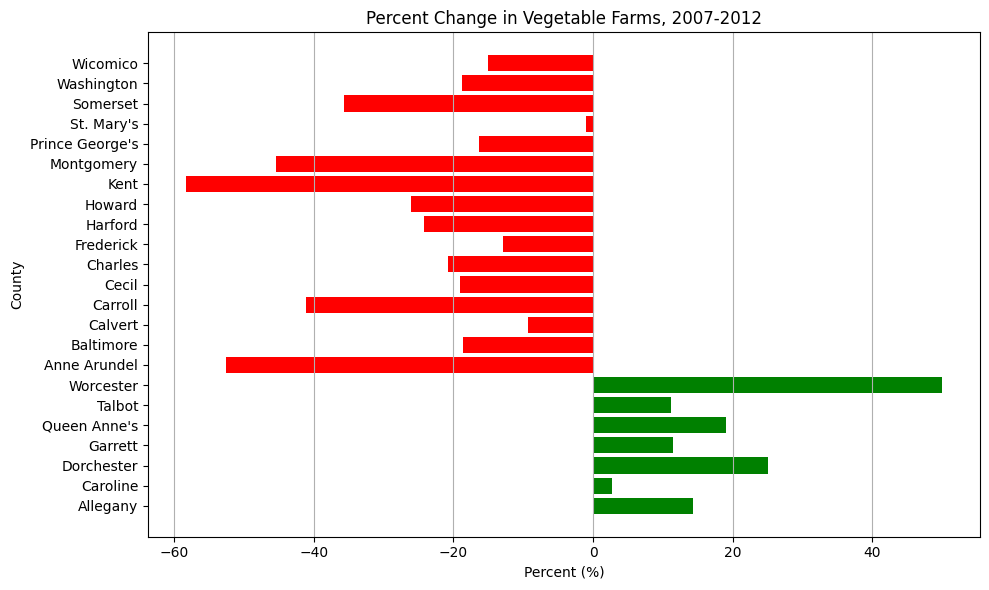

```python
# Bar Graph of Percent Change for Vegetable Farms from 2007 to 2012

df4_FEA_local_vegfarmspct['PCH_FRESHVEG_FARMS_07_12'] = pd.to_numeric(df4_FEA_local_vegfarmspct['PCH_FRESHVEG_FARMS_07_12'], errors='coerce')

positive_changes = df4_FEA_local_vegfarmspct[df4_FEA_local_vegfarmspct['PCH_FRESHVEG_FARMS_07_12'] > 0]
negative_changes = df4_FEA_local_vegfarmspct[df4_FEA_local_vegfarmspct['PCH_FRESHVEG_FARMS_07_12'] < 0]

plt.figure(figsize=(10, 6))

plt.barh(positive_changes['County'], positive_changes['PCH_FRESHVEG_FARMS_07_12'], color='green')
plt.barh(negative_changes['County'], negative_changes['PCH_FRESHVEG_FARMS_07_12'], color='red')

plt.xlabel('Percent (%)')
plt.ylabel('County')
plt.title('Percent Change in Vegetable Farms, 2007-2012')
plt.grid(axis='x')

plt.tight_layout()
plt.show()
```

##### **What do we see?**

There were many counties that decreased in vegetable farm counts. According to the Maryland Farms dataset, 2007 peaked with the number of farms, so the patterns exhibited here validate that data.

**Food Environmental Atlas Analysis Closing Summary**

This dataset provides insight on the locally-sourced food scene. We are able to see that in a 5 year span, 7 out of the 23 Maryland counties have increased in their count of vegetable farms while the others have decreased. Another important fact is that in 2015, Garrett County reports not having a farm to school program, which is important for nurturing local-sourced food communities. Anne Arundel, Baltimore, Frederick, Montgomery, and Prince George's county have double-digit count farms that report selling different type of products, and this was reported in 2018.